# Depersonalized extended contact and injunctive norms about cross-group friendship impact intergroup orientations - ScienceDirect

### 7.2. Results and discussion

#### 7.2.1. Positive intergroup orientations

We submitted positive intergroup orientations to a 3 (DEC: no vs. low vs. high DEC) × 3 (injunctive norm source: ingroup vs. outgroup vs. control) ANOVA. This analysis showed significant main effects of DEC, *F*(2,352) = 18.31, *p* < .001, η<sup>2</sup><sub>p</sub> = 0.094, 90% CI [0.049; 0.142], and injunctive norm source, *F*(2,352) = 12.75, *p* < .001, η<sup>2</sup><sub>p</sub> = 0.068, 90% CI [0.029; 0.110]. In particular, Tukey post-hoc analyses showed that participants in the ingroup norms condition expressed more positive intergroup orientations (*M* = 3.54, *SD* = 1.20), relative to participants in the outgroup norms condition (*M* = 2.96, *SD* = 1.13), and the control condition (*M* = 2.79, *SD* = 1.43), *p*s < 0.001. No significant difference in desire for contact emerged between participants in the outgroup norms and control conditions, *p* = .573. Moreover, these main effects were qualified by a significant interaction between DEC and injunctive norm source, *F*(4,352) = 5.28, *p* < .001, η<sup>2</sup><sub>p</sub> = 0.057, 90% CI [0.017; 0.091] (see Fig. 3). Among participants in the no DEC condition, positive intergroup orientations did not significantly differ depending on whether support for cross-group friendships came from an ingroup source (*M* = 2.64, *SD* = 0.98), an outgroup source (*M* = 2.92, *SD* = 1.09), or whether no information about normative support was given (*M* = 2.53, *SD* = 1.36), *F*(2,352) = 1.10, *p* = .334, η<sup>2</sup><sub>p</sub> = 0.006, 90% CI [0.000; 0.023]. However, positive intergroup orientations did significantly differ depending on the source of normative support among participants in the low DEC condition, *F*(2,352) = 11.73, *p* < .001, η<sup>2</sup><sub>p</sub> = 0.062, 90% CI [0.025; 0.104]. In particular, intergroup orientations were more positive among participants who received normative support for cross-group friendship from an ingroup source (*M* = 3.63, *SD* = 1.05) than among those who received normative support from an outgroup source (*M* = 2.82, *SD* = 1.31), or who received no normative support information (*M* = 2.38, *SD* = 1.39), *p*s < 0.001. The difference between those who received normative support from an outgroup source or received no normative support information was not significant, *p* = .122. Similarly, positive intergroup orientations differed significantly depending on the source of normative support among participants in the high DEC condition, *F*(2,352) = 11.62, *p* < .001, η<sup>2</sup><sub>p</sub> = 0.062, 90% CI [0.025; 0.103]. Intergroup orientations were more positive among participants who received normative support for cross-group friendship from an ingroup source (*M* = 4.21, *SD* = 1.01), than among those who received normative support from an outgroup source (*M* = 3.14, *SD* = 0.95), or who received no normative support information (*M* = 3.41, *SD* = 1.36), *p*s = 0.001 and 0.003, respectively. The difference between those who received normative support from an outgroup source or received no normative support information was not significant, *p* = .343.

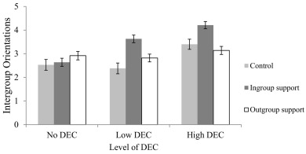

1. [Download : Download high-res image (88KB)](https://ars-els-cdn-com.ezproxy.spu.edu/content/image/1-s2.0-S0022103117305462-gr3_lrg.jpg)
2. [Download : Download full-size image](https://ars-els-cdn-com.ezproxy.spu.edu/content/image/1-s2.0-S0022103117305462-gr3.jpg)

Fig. 3. Positive intergroup orientations as a function of depersonalized extended contact (DEC) norms and source of injunctive norms (Experiment 3). Error bars represent standard error.

Results of Experiment 3 complemented and extended findings from the previous experiments. DEC and injunctive norms once again were shown to be important predictors of positive intergroup orientations. In particular, intergroup orientations were enhanced by normative support from the ingroup, as compared to normative support from the outgroup, or an absence of normative support. Of special interest is the finding that DEC and injunctive norms interact in predicting the intergroup outcomes. When there is no DEC, positive intergroup orientations do not differ depending on whether the source of normative support is the ingroup or outgroup. In contrast, when people believe that members of their group have at least some contact with outgroup members (low or high), normative support from the ingroup yields more positive intergroup orientations as compared to normative support from the outgroup, or when no information about normative support is given. Once again the effect size of the interaction was medium. The effect sizes of both extended contact and norms were medium-high.

Indeed, results from Experiment 3 indicate that outgroup norms had relatively little influence on Spaniards' intergroup orientations. This finding is consistent with prior work showing that ingroup members tend to be more influential and persuasive than outgroup members (Ariyanto et al., 2006; Mackie et al., 1990; Terry & Hogg, 1996), and specifically in the context of encouraging positive [intergroup relations](https://www-sciencedirect-com.ezproxy.spu.edu/topics/psychology/intergroup-relations) (Gómez et al., 2008). At the same time, it could be argued that outgroup norms supporting cross-group friendships are less influential because people suspect that those norms are merely based on utilitarian motives and not on a genuine interest in integration. Just as suspicion of ulterior motives has been shown to reduce persuasion in other contexts (Eagly et al., 1978), it is possible that Spaniards may perceive immigrants' support for cross-group friendship as being driven by instrumental concerns (e.g., to obtain benefits or gain employment) and to promote their group's advancement.

In Experiments 4–5, we therefore examine the extent to which Spaniards attribute utilitarian and integration motives to immigrant outgroup members, and how these motives might mediate the effects of DEC and injunctive norms on intergroup orientations. Extending the prior experiments, we also include judgments about a behavioral outcome in Experiments 4–5, by testing whether DEC and injunctive norms predict not only positive intergroup orientations, but also how these norms independently and interactively predict judgments about donations to ingroup and outgroup organizations.

Thus far, we have consistently found that intergroup orientations are significantly more positive in the high DEC condition than in the low and no DEC conditions, regardless of whether there is normative support for cross-group friendships or not. We also found that intergroup orientations significantly differ between the low DEC and no DEC conditions when injunctive norms are present. Since these two conditions are the most theoretically relevant in testing the role of extended contact, we focused exclusively on distinguishing between the low and no DEC conditions in Experiments 4–5. Regarding the role of injunctive norms, in Experiment 4 participants learnt about outgroup norms whereas in Experiment 5 we returned to our principal focus on ingroup support for cross-group friendships, as examined in Experiments 1 and 2. In both experiments 4 and 5 we included a measure of judgments about donations and measures of participants' attribution of utilitarian and integration motives to outgroup members as potential mediators of the experimental effects. Finally, a common limitation of the previous studies is that the effects could potentially be produced because the experimental manipulation appears more credible in some cases than in others (i.e., when the information comes from an ingroup source). Studies 4 and 5 included a manipulation check to address this alternative explanation.

## 8. Experiment 4

Experiment 4 was conducted to test whether outgroup norms supporting cross-group friendships do not exert influence on intergroup orientations because participants attribute outgroup members' interest in contact to utilitarian motives rather than a genuine desire for integration. To that end, we checked whether the effect of DEC and outgroup injunctive norms about intergroup contact on orientations and judgments about behavior toward outgroup members was mediated by the attribution of integrative or utilitarian motives to outgroup members.

Based on the results of Experiment 3, we did not expect to find main or interactive effects of DEC and outgroup injunctive norms on any of the dependent variables with the exception of the attribution of utilitarian motives to outgroup members. In this case, we expected to find an interactive effect of DEC and injunctive norms, such that the normative support from the outgroup should affect the attribution of utilitarian motives in the low DEC condition, but not in the no DEC condition. More specifically, learning about low intergroup contact would intensify the perception of utilitarian motives when outgroup members support intergroup contact as compared with the control condition in which no information about normative support is given. Learning that outgroup members support intergroup contact could increase suspicion when there is intergroup contact. When there is no DEC, there is not an objective basis to suspect that outgroup members have ulterior motives.

### 8.1. Method

#### 8.1.1. Participants and design

Three hundred fifty-two Spaniards (205 women, 147 men; mean age = 35.79, *SD* = 13.24) voluntarily participated in the present study. We employed the snowball technique for data collection. Students from the *Universidad Nacional de Educación a Distancia* (UNED) sent a link soliciting the participation of friends, colleagues or acquaintances. Each participant was randomly assigned to one of four conditions of a 2 (DEC: none vs. low) × 2 (normative support for cross-group friendship: outgroup support vs. control) design. We estimated that a sample of at least 300 participants would yield power of 95% to detect a small-medium effect.

#### 8.1.2. Procedure and materials

To shorten the questionnaire, we dispensed with the control variables and the final questions about the origin of immigrants, as we found no significant differences in experimental effects associated with these variables. Participants were randomly assigned to receive one of four versions of a fictitious newspaper article, which were varied to represent the factorial combination of the DEC manipulation (no vs. low contact) and the injunctive outgroup norms manipulation (outgroup support vs. control). We used the same instructions as in Experiment 3.

After reading the newspaper article, participants were asked to respond to two counterbalanced scales designed to assess utilitarian and integration motives for contact, with item responses ranging from 0 (*totally disagree*) to 6 (*totally agree*).

*Utilitarian motives* were assessed using five items, through which participants were asked the extent to which they believed immigrants would support having Spanish friends because it is a way to “get things more easily”, “get a job”, “get social benefits”, “get access to the health system”, and “satisfy material interests”. An [exploratory factor analysis](https://www-sciencedirect-com.ezproxy.spu.edu/topics/psychology/exploratory-factor-analysis) showed that these items loaded onto one factor (loadings ranging from 0.86 to 0.90) and were substantially interrelated (α = 0.92).

*Integration motives* were assessed using six items, through which participants were asked the extent to which they believed immigrants would support having Spanish friends because they want to: “integrate in our society”, “better understand our life in general”, “understand our culture and customs”, “participate in our life”, “establish bonds of true friendship with us”, and “maintain their cultural heritage but also adopt ours”. An exploratory factor analysis showed that these items loaded onto one factor (loadings ranging from 0.74 to 0.90) and were substantially interrelated (α = 0.92).<sup>4</sup>

Participants then completed the same questions as in Experiments 1–3 concerning their positive intergroup orientations (α = 0.88). Additionally, participants were informed that the Ministry of Science provided five euros to be donated for social causes in relation to each research participant recruited for the study. Participants were asked to decide whether this money would be given exclusively to, or shared between: (a) a non-governmental organization that helps low-income Spaniards, or/and (b) a non-governmental organization that works to integrate immigrants. Participants indicated the amount of money (0 to 5 euros), which could not exceed five euros, they would like to give to each organization.

Near the end of the questionnaire, participants completed three additional items as a manipulation check to assess the credibility of the newspaper article they read. Specifically, participants were asked to indicate the extent to which they considered the article to be credible, realistic, and convincing. Responses to these items were scored on a scale ranging from 0 (totally disagree) to 6 (totally agree), and scores on the three items were averaged to create a composite measure of article credibility (α = 0.92). Each dependent measure was then submitted to a 2 (intergroup contact: none vs. low) × 2 (normative support: support vs. control) ANOVA.

### 8.2. Results and discussion

#### 8.2.1. Credibility of the newspaper article

As intended, there were no differences in rated article credibility as a function of the independent variables, *F*(1,348) = 0.12, *p* = .721, η<sup>2</sup><sub>p</sub> = 0.000, 90% CI [0.000; 0.014] for DEC, *F*(1,348) = 0.25, *p* = .620, η<sup>2</sup><sub>p</sub> = 0.001, 90% CI [0.000; 0.016] for norms, and *F*(1,348) = 1.12, *p* = .291, η<sup>2</sup><sub>p</sub> = 0.003, 90% CI [0.000; 0.025] for the interaction effect. A *t*-test considering the midpoint of the scale (3) revealed that participants perceived the article as credible, *t*(351) = 12.97, *p* < .001, 95% CI [0.776; 1.053], *M* = 3.91, *SD* = 1.32.

#### 8.2.2. Dependent variables

Table 2 shows the descriptive statistics and correlations between the potential mediators and outcome variables. Utilitarian reasons correlated negatively with all variables, whereas integrative reasons correlated positively. Scores on positive intergroup orientations and donation toward outgroup members were significantly correlated.

Table 2. Experiment 4. Descriptive statistics and correlations.

|  | *M* | *SD* | 1 | 2 | 3 | 4 |
| --- | --- | --- | --- | --- | --- | --- |
| 1. Utilitarian reasons (0–6) | 2.74 | 1.42 | – |  |  |  |
| 2. Integrative reasons (0–6) | 3.86 | 1.23 | −0.32 | – |  |  |
| 3. Intergroup orientations (0–6) | 3.78 | 1.21 | −0.28 | 0.60 | – |  |
| 4. Donation (0–5) | 1.90 | 1.20 | −0.22 | 0.45 | 0.51 | – |

Note: All *p*s < 0.01.

All dependent measures were submitted to a 2 (DEC: no vs. low contact) × 2 (injunctive norms: outgroup support vs. control) MANOVA. The multivariate effect of DEC was significant, *F*(4, 345) = 4.18, *p* = .003, Pillai's Trace = 0.05, η<sup>2</sup> = 0.046, but the effect of norms was not, *F*(4, 345) = 1.24, *p* = .292, Pillai's Trace = 0.01, η<sup>2</sup> = 0.014. The multivariate effect of the interaction between DEC and norms was only marginal, *F*(4, 345) = 2.26, *p* = .062, Pillai's Trace = 0.03, η<sup>2</sup> = 0.026. The multivariate effect of norms was not significant in either the low, *F*(4, 345) = 2.05, *p* = .087, Pillai's Trace = 0.03, η<sup>2</sup> = 0.023, or the no, *F*(4, 345) = 1.46, *p* = .215, Pillai's Trace = 0.02, η<sup>2</sup> = 0.017, DEC condition. Significant univariate effects were found only for utilitarian reasons, but not for the remaining dependent variables, as described below.

##### 8.2.2.1. Utilitarian reasons

The univariate *F* test on utilitarian reasons showed a small, but significant effect of the interaction between DEC and normative support, *F*(1,348) = 6.05, *p* = .014, η<sup>2</sup><sub>p</sub> = 0.017, 90% CI [0.002; 0.046]. Among participants in the no DEC condition, the effect of normative support from the outgroup was not significant, *F*(1,384) = 1.78, *p* = .183, η<sup>2</sup><sub>p</sub> = 0.005, 90% CI [0.000; 0.025]. The attribution of utilitarian reasons to outgroup members among participants in the support (*M* = 2.38, *SD* = 1.29) and control conditions (*M* = 2.67, *SD* = 1.47) was similar. In contrast, in the low DEC condition, the effect of normative support was small, but significant, *F*(1,348) = 4.60, *p* = .033, η<sup>2</sup><sub>p</sub> = 0.013, 90% CI [0.001; 0.039]. The attribution of utilitarian reasons to outgroup members among participants in the support condition (*M* = 3.19, *SD* = 1.28) was higher than in the control condition (*M* = 2.74, *SD* = 1.56). The main effect of the DEC manipulation was significant, *F*(1,348) = 8.72, *p* = .003, η<sup>2</sup><sub>p</sub> = 0.024, 90% CI [0.005; 0.057], but the main effect of norms was not significant, *F*(1,348) = 0.32, *p* = .573, η<sup>2</sup><sub>p</sub> = 0.001, 90% CI [0.000; 0.013].

No significant effects emerged on the univariate *F* tests on the remaining variables. For integrative reasons, the effects were: *F*(1,348) = 2.15, *p* = .143, η<sup>2</sup><sub>p</sub> = 0.006, 90% CI [0.000; 0.032] for DEC, *F*(1,348) = 1.40, *p* = .237, η<sup>2</sup><sub>p</sub> = 0.004, 90% CI [0.000; 0.027] for norms, and *F*(1,348) = 0.05, *p* = .817, η<sup>2</sup><sub>p</sub> = 0.000, 90% CI [0.000; 0.007] for the interaction. For orientations, the effects were: *F*(1,348) = 0.73, *p* = .392, η<sup>2</sup><sub>p</sub> = 0.002, 90% CI [0.000; 0.022] for DEC, *F*(1,348) = 0.57, *p* = .452, η<sup>2</sup><sub>p</sub> = 0.002, 90% CI [0.000; 0.020] for norms, and *F*(1,348) = 2.80, *p* = .095, η<sup>2</sup><sub>p</sub> = 0.008, 90% CI [0.000; 0.036] for the interaction. For donations toward outgroup members, the effects were: *F*(1,348) = 0.63, *p* = .428, η<sup>2</sup><sub>p</sub> = 0.002, 90% CI [0.000; 0.021] for DEC, *F*(1,348) = 0.72, *p* = .395, η<sup>2</sup><sub>p</sub> = 0.002, 90% CI [0.000; 0.022] for norms, and *F*(1,348) = 0.16, *p* = .691, η<sup>2</sup><sub>p</sub> = 0.000, 90% CI [0.000; 0.015] for the interaction.

Experiment 4 replicates previous findings in that we found no effects of outgroup norms on intergroup orientations. Outgroup norms did not affect donations either. We reasoned that the absence of significant effects might be due to the increased attribution of utilitarian motives to outgroup members when participants are aware that outgroup members support having Spanish friends. In fact, we obtained a significant interactive effect of DEC and injunctive norms on the attribution of utilitarian motives. Learning that outgroup members approve intergroup contact increased the attribution of these motives when participants knew that ingroup members actually have one or two immigrant friends. However, normative support was not important when participants were aware that most ingroup members did not have immigrant friends. These results suggest that the enhanced perception that outgroup members' interest in intergroup contact is not genuine could inhibit the positive effect of normative support that emerged in the previous experiments when the ingroup was the source of such support.

However, when participants are aware that ingroup members not only have contact with outgroup members but support cross-group friendship, they could infer that outgroup members are trustworthy. Previous research (Stangor et al., 2001) showed that providing information about racial ingroup beliefs can modify the stereotypes related to outgroup members. We conjecture that learning that ingroup members support and actually have intergroup contact might also influence the way people explain outgroup members' behavior. In particular, we expect that learning that ingroup members support, and actually have some degree of, contact with outgroup members should increase the attribution of integration motives to outgroup members and, in turn, promote positive intergroup orientations.

In Experiment 5 we test whether the manipulations of DEC and ingroup support affect intergroup orientations by modifying the attribution of integrative motives to outgroup members. As in the previous studies, we predicted a main effect of DEC such that learning about low levels of DEC would predict more positive intergroup orientations and greater donation of money to an outgroup organization than learning about no DEC. We also expected a main effect of injunctive norms, such that learning about ingroup support for cross-group friendship would produce more positive intergroup orientations and greater donations to an outgroup organization than receiving no information about ingroup support. Importantly, we also predicted an interaction between DEC and injunctive norms, such that ingroup support would predict more positive intergroup orientations and greater donation in the low DEC condition, but not in the no DEC condition. Moreover, we expected that these interactive effects would be mediated by the attribution of integration motives to outgroup members, and not by the attribution of utilitarian motives.

## 9. Experiment 5

Using procedures virtually identical to those used in Experiment 1, Experiment 5 tested how DEC and injunctive norms contribute to predicting positive intergroup orientations and intergroup behavior in the form of donations toward an outgroup organization.

### 9.1. Method

#### 9.1.1. Participants and design

Two hundred eighty-nine Spaniards (175 women, 114 men; mean age = 34.95, *SD* = 13.11) voluntarily participated online in the present study. We employed the snowball technique for data collection. Students from the *Universidad Nacional de Educación a Distancia* (UNED) sent a link soliciting the participation of friends, colleagues or acquaintances.

Each participant was randomly assigned to one of four conditions in a 2 (descriptive norms: no vs. low DEC) × 2 (injunctive norms: ingroup support vs. control) factorial design. Since we suspected that the effect of our manipulations on judgments about behavior would be weaker than on behavioral intentions, we recruited a larger sample than in Experiments 1–2, although the experimental design was simpler. We estimated that a sample of approximately 300 participants would provide power of 95% to detect a small effect size.

#### 9.1.2. Procedure and materials

Participants were randomly assigned to receive one of four versions of a fictitious newspaper article, which were varied to represent the factorial combination of the DEC (no vs. low contact) and the normative support manipulations (support vs. control). We used the same instructions as in Experiment 3.

After reading the newspaper article, participants completed the same questions as in Experiment 4 concerning utilitarian and integration motives, αs > 0.89, their positive intergroup orientations (α = 0.88), monetary donation (0–5 euros) to outgroup members, and credibility of the newspaper article they read, α = 0.93.

### 9.2. Results and discussion

The manipulation check on the credibility of the newspaper article was submitted to a 2 (DEC: no vs. low) × 2 (injunctive norms: ingroup support vs. control) ANOVA. As intended, there were no differences in rated article credibility as a function of the independent variables, *F*(1,285) = 0.45, *p* = .503, η<sup>2</sup><sub>p</sub> = 0.002, 90% CI [0.000; 0.023] for DEC, *F*(1,285) = 0.33, *p* = .564, η<sup>2</sup><sub>p</sub> = 0.001, 90% CI [0.000; 0.022] for norms, and *F*(1,285) = 1.55, *p* = .215, η<sup>2</sup><sub>p</sub> = 0.005, 90% CI [0.000; 0.035] for the interaction effect. A *t*-test comparing the mean score (*M* = 3.96) of credibility to the midpoint of the scale (3.0) revealed that participants generally perceived the article as credible, *t*(288) = 12.80, *p* < .001, 95% CI [0.816; 1.112].

#### 9.2.1. Dependent variables

Table 3 shows the descriptive statistics and correlations between the potential mediators and outcome variables. Utilitarian reasons correlated negatively with all variables, whereas integrative reasons correlated positively. Scores on positive intergroup orientations and donations were significantly correlated (see Table 3). All dependent measures were submitted to a 2 (DEC: no vs. low DEC) × 2 (injunctive norms: ingroup support vs. control) MANOVA.

Table 3. Experiment 5. Descriptive statistics and correlations.

|  | *M* | *SD* | 1 | 2 | 3 | 4 |
| --- | --- | --- | --- | --- | --- | --- |
| 1. Utilitarian reasons (0–6) | 2.63 | 1.48 | – |  |  |  |
| 2. Integrative reasons (0–6) | 3.90 | 1.09 | −0.34 | – |  |  |
| 3. Intergroup orientations (0–6) | 3.66 | 1.19 | −0.30 | 0.62 | – |  |
| 4. Donation (0–5) | 1.97 | 1.02 | −0.31 | 0.45 | 0.50 | – |

Note: All *p*s < 0.01.

The multivariate effect of DEC was significant, *F*(4, 281) = 4.88, *p* = .001, Pillai's Trace = 0.06, η<sup>2</sup> = 0.065, but the effect of norms was not, *F*(4, 281) = 1.18, *p* = .320, Pillai's Trace = 0.02, η<sup>2</sup> = 0.017. The main effect of DEC was qualified by a multivariate effect of the interaction, *F*(4, 281) = 3.79, *p* = .005, Pillai's Trace = 0.51, η<sup>2</sup> = 0.051. The multivariate effect of norms was significant in the low DEC condition, *F*(4, 281) = 4.04, *p* = .003, Pillai's Trace = 0.54, η<sup>2</sup> = 0.054, but not in the no DEC condition, *F*(4, 281) = 0.90, *p* = .466, Pillai's Trace = 0.01, η<sup>2</sup> = 0.013. Significant univariate effects were found for all dependent variables except for utilitarian reasons, as described below.